# Bootstrap analysis: Determine top performers

Verena Chung, Robert Allaway (Sage Bionetworks)

2021-09-01

## Introduction

In order to declare top-performers for a DREAM challenge, we need to assess if there are any “tied” methods, that is, methods that are not substantially different in performance. We determine this using a bootstrapping (sampling with replacement) approach to determing how a submission would score in different scenarios (that is - when only considering resampled sets of the values to be predicted). Specifically, we sample with replacement all of the submitted predictions and the gold standard and score the prediction files. We repeat this for at total of 1000-10000 samples to obtain a distribution of scores for each participant. We then calculate a Bayes factor relative to the best-scoring method, to see if any of the other methods are within a certain threshold. Smaller Bayes factors indicate more similar performance while larger Bayes factors indicate more disparate performance. We use a Bayes factor of 3 as a cutoff to indicate a tie.

## Setup

First, import packages for data manipulation and retrieve prediction data, gold standard data, and the template for use in the scoring code. Don’t forget to set a seed!

```r
set.seed(98109)

library(tidyverse)
library(reticulate)
library(challengescoring)
library(ggplot2)
library(reactable)

# Synapse setup to use `reticulate`
use_condaenv("ra2dream", required = T)
synapseclient <- reticulate::import('synapseclient')
syn <- synapseclient$Synapse()
```

#### Functions

Additionally, define functions to help with the scoring algorithms.

```r
#
calculate_weight <- function(x){
  weight <- dplyr::if_else(x == 0, 1,
            dplyr::if_else(x == 1, 2,
            dplyr::if_else(x>=2 & x<=3, 2.143547,
            dplyr::if_else(x>=4 & x<=7, 3.863745,
            dplyr::if_else(x>=8 & x<=20, 8,
            dplyr::if_else(x>=21 & x<=55, 16,
            dplyr::if_else(x>=56 & x<=148, 32,
            dplyr::if_else(x>=148, 64, 0))))))))
  return(weight)
}

#
sum_weighted_error <- function(gold, pred, weight){
  sum(weight*abs(gold - pred))
}

#
rmse <- function(gold, pred){
  sqrt(mean((gold - pred) ** 2))
}

# Scoring function for joint weighted sum RMSE.
score_weighted_rmse <- function(df, pred) {
  df$pred_score <- pred
  df %>% group_by(Patient_ID, weight) %>%
    summarize(patient_rmse = rmse(log2(score+1), log2(pred_score+1))) %>%
    ungroup() %>%
    summarize(result= sum(weight*patient_rmse)/sum(weight)) %>%
    pluck("result")
}
```

#### Goldstandard

The assessment of subchallenge 1 utilizies known SvH scores and subchallenges 2 & 3 known individual joint narrowing and erosion scores. After adding a weight for each joint score, split the goldstandard accordingly.

```r
gold <- read.csv(syn$get("syn22296988")$path) %>%
  mutate(weight = calculate_weight(Overall_Tol))

gold.sc1 <- gold %>%
  select(Patient_ID, Overall_Tol, weight)

gold_joints <- gold %>%
  select(-Overall_Tol) %>%
  gather('joint', 'score', -Patient_ID, -weight)
```

## Bootstrap Submissions

Read in prediction files, combine, then bootstrap the predictions + a gold standard 1000 times to calculate 1000 scores per prediction.

```r
N <- 1000  # number of bootstrapped scores to be calculated


##filtered out Sha2256:6cb.... because this was the wrong baseline model; we re-ran with the correct baseline

query <- syn$tableQuery(
  "SELECT id, prediction_fileid, submitterid, createdOn,
    sc1_weighted_sum_error AS sc1,
    sc2_joint_weighted_sum_rmse AS sc2,
    sc3_joint_weighted_sum_rmse AS sc3
  FROM syn22236264 WHERE status = 'ACCEPTED' AND
    submitterid <> 3408914 AND
    submitterid <> 3399952 AND
    dockerdigest not in ('sha256:6cb365830745c5d368bcd128a3a1b750ace801da281356a5a623237408c10a3d')")$asDataFrame() %>%
   ## remove participants that did not submit writeup to final round (3408914 and 3399952)
  group_by(submitterid) %>%
  slice(which.max(createdOn)) %>%
  select(-createdOn)

# For easier identification, replace each team/participant's submitterid with
# their team name/username.
query$submitterid <- as.character(query$submitterid)
team_names <- sapply(query$submitterid, function(sub) {
  name <- tryCatch({
    syn$getUserProfile(sub)$userName
  }, error = function(err) {
    syn$getTeam(sub)$name
  })
  return(name)
})
query$submitterid <- team_names

pred_filenames <- lapply(query$prediction_fileid, function(id) {
  syn$get(id)$path
})
names(pred_filenames) <- team_names

# Before bootstrapping, rearrange the teams by rank, where left = better
# performance and right = not-as-great performance.

### SC1
submissions.sc1 <- lapply(names(pred_filenames), function(team) {
  read.csv(pred_filenames[[team]]) %>%
    mutate_at(vars(-Patient_ID), ~ replace(., which(.<0), 0)) %>%
    select(Patient_ID, Overall_Tol) %>%
    rename(!!team := Overall_Tol)
}) %>%
  reduce(left_join, by="Patient_ID") %>%
  left_join(gold.sc1, by="Patient_ID") %>%
  rename(gold = Overall_Tol)

results.sc1 <- submissions.sc1[,c("gold", "weight", (query %>% arrange(sc1))$submitterid)]

bs_indices.sc1 <- matrix(1:nrow(results.sc1), nrow(results.sc1), N) %>%
  apply(2, sample, replace = T)

boot.sc1 <- apply(bs_indices.sc1, 2, function(ind) {
  tmp.gold <- results.sc1[ind,c(1:2)]
  apply(results.sc1[ind, -c(1:2)], 2, function(pred) {
    sum_weighted_error(
      log2(tmp.gold$gold + 1),
      log2(pred + 1),
      tmp.gold$weight
    ) / sum(tmp.gold$weight)
  })
}) %>%
  t()

### SC2
submissions.sc23 <- lapply(names(pred_filenames), function(team) {
  read.csv(pred_filenames[[team]]) %>%
    select(-Overall_Tol) %>%
    gather('joint', !!team, -Patient_ID)
}) %>%
  reduce(left_join, by=c("Patient_ID", "joint")) %>%
  left_join(gold_joints, by=c("Patient_ID", "joint"))

results.sc2 <- submissions.sc23[, c(
    "Patient_ID", "joint", "weight", "score", (query %>% arrange(sc2))$submitterid
  )] %>%
  filter(grepl(".+_J__.+", joint))

bs_indices.sc2 <- matrix(1:nrow(results.sc2), nrow(results.sc2), N) %>%
  apply(2, sample, replace = T)

boot.sc2 <- apply(bs_indices.sc2, 2, function(ind) {
  tmp.gold <- results.sc2[ind, c(1:4)]
  apply(results.sc2[ind, -c(1:4)], 2, function(pred) {
    score_weighted_rmse(tmp.gold, pred)
  })
}) %>%
  t()

### SC3
results.sc3 <- submissions.sc23[, c(
    "Patient_ID", "joint", "weight", "score", (query %>% arrange(sc3))$submitterid
  )] %>%
  filter(grepl(".+_E__.+", joint))

bs_indices.sc3 <- matrix(1:nrow(results.sc3), nrow(results.sc3), N) %>%
  apply(2, sample, replace = T)

boot.sc3 <- apply(bs_indices.sc3, 2, function(ind) {
  tmp.gold <- results.sc3[ind, c(1:4)]
  apply(results.sc3[ind, -c(1:4)], 2, function(pred) {
    score_weighted_rmse(tmp.gold, pred)
  })
}) %>%
  t()
```

## Bayes Factor Analysis

Use our `challengescoring` package to compute Bayes factors using a matrix of scores, setting the `refPredIndex` as the number of the column that contains the top prediction (the reference prediction).

In addition to computing BF against the top performer, we are also interested in comparing against all columns. Some tweaking to the computation will be required, as the reference index may no longer be the best, which in consequence, means the inversion of K will be dependent on which submission it is being compared with.

```r
# Top performer: Team Shirin
bayes_top.sc1 <- computeBayesFactor(boot.sc1, refPredIndex=1, invertBayes=F) %>%
  as_tibble(rownames = "submission") %>%
  rename(bayes = value)

# Top performer: Hongyang Li and Yuanfang Guan (column 1)
bayes_top.sc2 <- computeBayesFactor(boot.sc2, refPredIndex=1, invertBayes=F) %>%
  as_tibble(rownames = "submission") %>%
  rename(bayes = value)

# Top performer: Gold Therapy (column 1)
bayes_top.sc3 <- computeBayesFactor(boot.sc3, refPredIndex=1, invertBayes=F) %>%
  as_tibble(rownames = "submission") %>%
  rename(bayes = value)

computeBayesFactorWhereRefIsNotBest <- function(bootstrapMetricMatrix,
                               refPredIndex,
                               invertBayes){

    M <- as.data.frame(bootstrapMetricMatrix - bootstrapMetricMatrix[,refPredIndex])
    K <- apply(M ,2, function(x) {
      k <- sum(x >= 0)/sum(x < 0)
      if(sum(x >= 0) > sum(x < 0)){
      return(k)
      }else{
      return(1/k)
      }
    })
    if(invertBayes == T){K <- 1/K}
    K[refPredIndex] <- 0

    return(K)
}

bayesFactorMatrix <- function(bootstrapMatrix) {
  names <- colnames(bootstrapMatrix)
  results <- purrr::map(1:ncol(bootstrapMatrix), function(ind) {
    computeBayesFactorWhereRefIsNotBest(bootstrapMatrix, refPredIndex=ind, invertBayes=F) %>%
      as.data.frame()
}) %>% bind_cols
  colnames(results) <- names
  results
}
```

### Subchallenge 1

| submission | bayes |
| --- | --- |
| Team Shirin | 0.00000 |
| Hongyang Li and Yuanfang Guan | 5.17284 |
| csabaibio | 165.66667 |
| Nc717 | Inf |
| zs_aicoe | Inf |
| NAD | Inf |
| Gold Therapy | Inf |
| Alpine Lads | Inf |
| RYM | Inf |
| CU_DSI_RA2_Challenge | Inf |

[output cut: 4 more lines]

|  | Team Shirin | Hongyang Li and Yuanfang Guan | csabaibio | Nc717 | zs_aicoe | NAD | Gold Therapy | Alpine Lads | RYM | CU_DSI_RA2_Challenge | kichuDL | RA2 Baseline Model | Aboensis V | Zbigniew Wojna |
| --- | --- | --- | --- | --- | --- | --- | --- | --- | --- | --- | --- | --- | --- | --- |
| Team Shirin | 0.00000 | 5.172840 | 165.666667 | Inf | Inf | Inf | Inf | Inf | Inf | Inf | Inf | Inf | Inf | Inf |
| Hongyang Li and Yuanfang Guan | 5.17284 | 0.000000 | 8.615385 | 141.857143 | Inf | Inf | Inf | Inf | Inf | Inf | Inf | Inf | Inf | Inf |
| csabaibio | 165.66667 | 8.615385 | 0.000000 | 9.204082 | 27.571429 | Inf | Inf | Inf | Inf | Inf | Inf | Inf | Inf | Inf |
| Nc717 | Inf | 141.857143 | 9.204082 | 0.000000 | 6.575758 | Inf | Inf | Inf | Inf | Inf | Inf | Inf | Inf | Inf |
| zs_aicoe | Inf | Inf | 27.571429 | 6.575758 | 0.000000 | 29.30303 | Inf | Inf | Inf | Inf | Inf | Inf | Inf | Inf |
| NAD | Inf | Inf | Inf | Inf | 29.303030 | 0.00000 | Inf | Inf | Inf | Inf | Inf | Inf | Inf | Inf |
| Gold Therapy | Inf | Inf | Inf | Inf | Inf | Inf | 0.00000 | 165.666667 | 16.543860 | Inf | Inf | Inf | Inf | Inf |
| Alpine Lads | Inf | Inf | Inf | Inf | Inf | Inf | 165.66667 | 0.000000 | 2.472222 | Inf | Inf | Inf | Inf | Inf |
| RYM | Inf | Inf | Inf | Inf | Inf | Inf | 16.54386 | 2.472222 | 0.000000 | Inf | Inf | Inf | Inf | Inf |
| CU_DSI_RA2_Challenge | Inf | Inf | Inf | Inf | Inf | Inf | Inf | Inf | Inf | 0.000000 | 7.928571 | Inf | 999.000000 | Inf |

[output cut: 4 more lines]

### Subchallenge 2

| submission | bayes |
| --- | --- |
| Hongyang Li and Yuanfang Guan | 0.00000 |
| Gold Therapy | 33.48276 |
| csabaibio | Inf |
| Zbigniew Wojna | Inf |
| Alpine Lads | Inf |
| Team Shirin | Inf |
| NAD | Inf |
| Nc717 | Inf |
| zs_aicoe | Inf |
| Aboensis V | Inf |

[output cut: 4 more lines]

|  | Hongyang Li and Yuanfang Guan | Gold Therapy | csabaibio | Zbigniew Wojna | Alpine Lads | Team Shirin | NAD | Nc717 | zs_aicoe | Aboensis V | RYM | kichuDL | CU_DSI_RA2_Challenge | RA2 Baseline Model |
| --- | --- | --- | --- | --- | --- | --- | --- | --- | --- | --- | --- | --- | --- | --- |
| Hongyang Li and Yuanfang Guan | 0.00000 | 33.48276 | Inf | Inf | Inf | Inf | Inf | Inf | Inf | Inf | Inf | Inf | Inf | Inf |
| Gold Therapy | 33.48276 | 0.00000 | 19.833333 | 332.333333 | 22.255814 | Inf | Inf | Inf | Inf | Inf | Inf | Inf | Inf | Inf |
| csabaibio | Inf | 19.83333 | 0.000000 | 9.752688 | 1.577320 | Inf | Inf | Inf | Inf | Inf | Inf | Inf | Inf | Inf |
| Zbigniew Wojna | Inf | 332.33333 | 9.752688 | 0.000000 | 7.264463 | 165.666667 | 499.000000 | 332.333333 | Inf | Inf | Inf | Inf | Inf | Inf |
| Alpine Lads | Inf | 22.25581 | 1.577320 | 7.264463 | 0.000000 | Inf | Inf | Inf | Inf | Inf | Inf | Inf | Inf | Inf |
| Team Shirin | Inf | Inf | Inf | 165.666667 | Inf | 0.000000 | 2.952569 | 1.949853 | Inf | Inf | Inf | Inf | Inf | Inf |
| NAD | Inf | Inf | Inf | 499.000000 | Inf | 2.952569 | 0.000000 | 1.801120 | Inf | Inf | Inf | Inf | Inf | Inf |
| Nc717 | Inf | Inf | Inf | 332.333333 | Inf | 1.949853 | 1.801120 | 0.000000 | Inf | Inf | Inf | Inf | Inf | Inf |
| zs_aicoe | Inf | Inf | Inf | Inf | Inf | Inf | Inf | Inf | 0 | Inf | Inf | Inf | Inf | Inf |
| Aboensis V | Inf | Inf | Inf | Inf | Inf | Inf | Inf | Inf | Inf | 0.00000 | 42.47826 | Inf | Inf | Inf |

[output cut: 4 more lines]

### Subchallenge 3

| submission | bayes |
| --- | --- |
| Gold Therapy | 0 |
| csabaibio | 124 |
| Hongyang Li and Yuanfang Guan | Inf |
| Team Shirin | Inf |
| Zbigniew Wojna | Inf |
| Alpine Lads | Inf |
| NAD | Inf |
| Nc717 | Inf |
| zs_aicoe | Inf |
| kichuDL | Inf |

[output cut: 4 more lines]

|  | Gold Therapy | csabaibio | Hongyang Li and Yuanfang Guan | Team Shirin | Zbigniew Wojna | Alpine Lads | NAD | Nc717 | zs_aicoe | kichuDL | Aboensis V | RYM | RA2 Baseline Model | CU_DSI_RA2_Challenge |
| --- | --- | --- | --- | --- | --- | --- | --- | --- | --- | --- | --- | --- | --- | --- |
| Gold Therapy | 0 | 124.0000 | Inf | Inf | Inf | Inf | Inf | Inf | Inf | Inf | Inf | Inf | Inf | Inf |
| csabaibio | 124 | 0.0000 | 249.000000 | 99.000000 | 141.857143 | 499.000000 | Inf | Inf | Inf | Inf | Inf | Inf | Inf | Inf |
| Hongyang Li and Yuanfang Guan | Inf | 249.0000 | 0.000000 | 1.832861 | 5.802721 | 3.048583 | 54.555556 | Inf | Inf | Inf | Inf | Inf | Inf | Inf |
| Team Shirin | Inf | 99.0000 | 1.832861 | 0.000000 | 3.484305 | 1.801120 | 8.900990 | Inf | Inf | Inf | Inf | Inf | Inf | Inf |
| Zbigniew Wojna | Inf | 141.8571 | 5.802721 | 3.484305 | 0.000000 | 1.967359 | 1.994012 | 999.0000 | Inf | Inf | Inf | Inf | Inf | Inf |
| Alpine Lads | Inf | 499.0000 | 3.048583 | 1.801120 | 1.967359 | 0.000000 | 5.024096 | 999.0000 | Inf | Inf | Inf | Inf | Inf | Inf |
| NAD | Inf | Inf | 54.555556 | 8.900990 | 1.994012 | 5.024096 | 0.000000 | 249.0000 | Inf | Inf | Inf | Inf | Inf | Inf |
| Nc717 | Inf | Inf | Inf | Inf | 999.000000 | 999.000000 | 249.000000 | 0.0000 | 141.8571 | Inf | Inf | Inf | Inf | Inf |
| zs_aicoe | Inf | Inf | Inf | Inf | Inf | Inf | Inf | 141.8571 | 0.0000 | Inf | Inf | Inf | Inf | Inf |
| kichuDL | Inf | Inf | Inf | Inf | Inf | Inf | Inf | Inf | Inf | 0 | Inf | Inf | Inf | Inf |

[output cut: 4 more lines]

## Plot Results

Plot boxplot of all scores, coloring the boxes by Bayes factor.

```r
plot_results <- function(results, bayes, subchallenge) {
  results %>%
    as_tibble() %>%
    gather(submission, bs_score) %>%
    left_join(bayes) %>%
    mutate(bayes_category=case_when(
      bayes == 0 ~ "Reference",
      bayes<=3 ~ "<3",
      bayes>=3 & bayes <5 ~ "3-5",
      bayes>=5 & bayes <10 ~ "5-10",
      bayes>=10 ~ ">10")) %>%
    ggplot(aes(
      x=fct_reorder(submission, -bs_score, .fun = mean),
      y=bs_score,
      color=bayes_category
    )) +
    geom_boxplot() +
    theme_bw() +
    scale_color_manual(values = c(
      "Reference"="#d32e36",
      '<3' = '#cf4d6f',
      "3-5" = "#cc7e85",
      "5-10" = '#c5afa4',
      ">10" = "#a8a6a4"),
      name = "Bayes Factor") +
    coord_flip() +
    labs(x="Team", y=paste("Bootstrapped", subchallenge, "Score"))
}
```

### Subchallenge 1

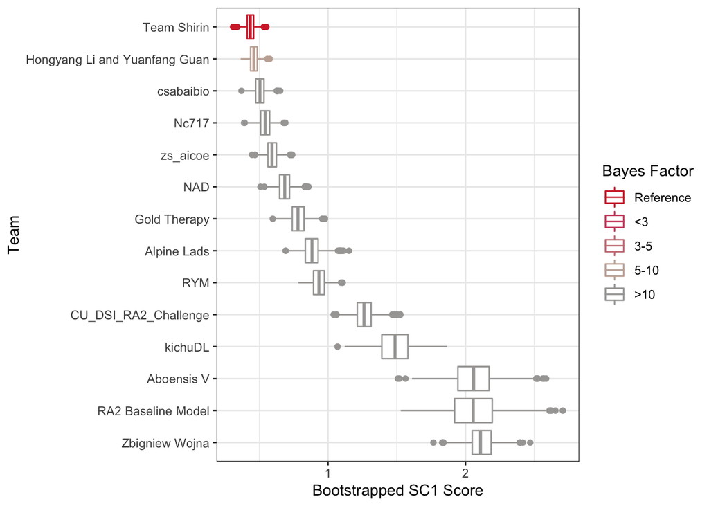

```r
sc1 <- plot_results(boot.sc1, bayes_top.sc1, "SC1")
sc1
```

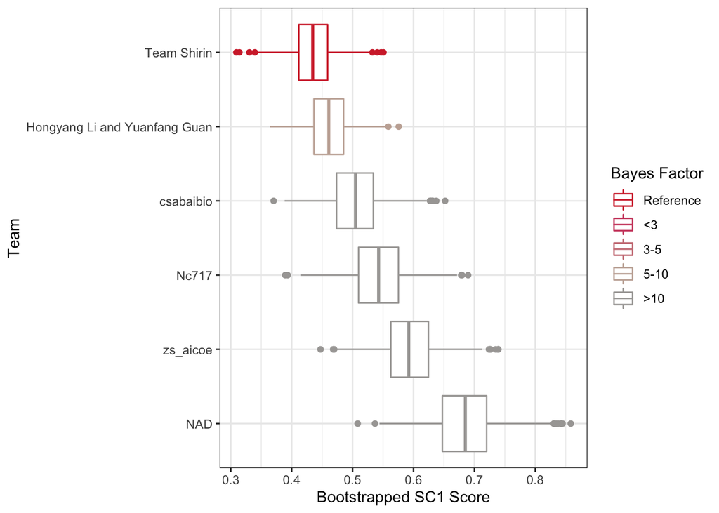

```r
plot_results(boot.sc1[,1:6], bayes_top.sc1, "SC1")
```

### Subchallenge 2

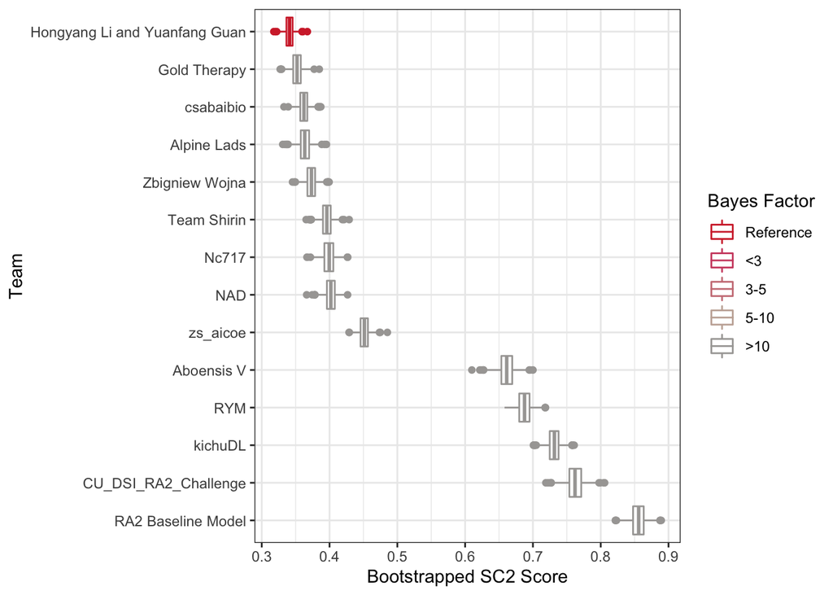

```r
sc2 <- plot_results(boot.sc2, bayes_top.sc2, "SC2")
sc2
```

### Subchallenge 3

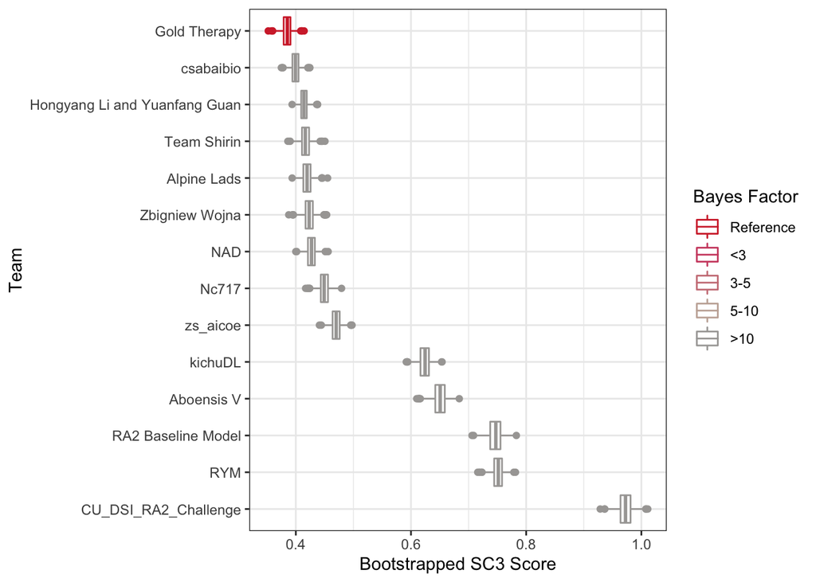

```r
sc3 <- plot_results(boot.sc3, bayes_top.sc3, "SC3")
sc3
```

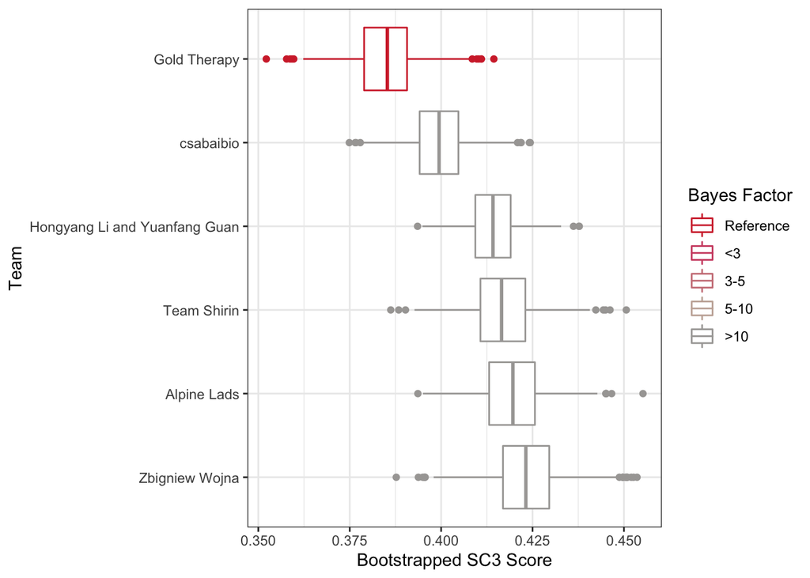

```r
plot_results(boot.sc3[,1:6], bayes_top.sc3, "SC3")
```